# Objective:

- Explore the dataset and extract actionable insights that will enable growth in the market.
- Perform univariate and multivariate analysis.
- Building customer profiles (characteristics of a customer) for the different products.
- Generate set recommendations that will help the company in targeting new customers.

# Data:

- Product - the model no. of the treadmill
- Age - in no of years, of the customer
- Gender - of the customer
- Education - in no. of years, of the customer
- Marital Status - of the customer
- Usage - Average times the customer wants to use the treadmill every week
- Fitness - Self rated fitness score of the customer (5 - very fit, 1 - very unfit)
- Income - of the customer
- Miles- expected to run

```python
import pandas as pd
import numpy as np
import seaborn as sns
import matplotlib.pyplot as plt
import warnings
warnings.filterwarnings('ignore')
```

```python
data=pd.read_csv(r'C:\Users\davis\OneDrive\Desktop\Python\Foundations\CardioGoodFitness.csv')
```

```python
data.head()
```

|  | Product | Age | Gender | Education | MaritalStatus | Usage | Fitness | Income | Miles |
| --- | --- | --- | --- | --- | --- | --- | --- | --- | --- |
| 0 | TM195 | 18 | Male | 14 | Single | 3 | 4 | 29562 | 112 |
| 1 | TM195 | 19 | Male | 15 | Single | 2 | 3 | 31836 | 75 |
| 2 | TM195 | 19 | Female | 14 | Partnered | 4 | 3 | 30699 | 66 |
| 3 | TM195 | 19 | Male | 12 | Single | 3 | 3 | 32973 | 85 |
| 4 | TM195 | 20 | Male | 13 | Partnered | 4 | 2 | 35247 | 47 |

```python
data.tail()
```

|  | Product | Age | Gender | Education | MaritalStatus | Usage | Fitness | Income | Miles |
| --- | --- | --- | --- | --- | --- | --- | --- | --- | --- |
| 175 | TM798 | 40 | Male | 21 | Single | 6 | 5 | 83416 | 200 |
| 176 | TM798 | 42 | Male | 18 | Single | 5 | 4 | 89641 | 200 |
| 177 | TM798 | 45 | Male | 16 | Single | 5 | 5 | 90886 | 160 |
| 178 | TM798 | 47 | Male | 18 | Partnered | 4 | 5 | 104581 | 120 |
| 179 | TM798 | 48 | Male | 18 | Partnered | 4 | 5 | 95508 | 180 |

```python
data.shape
```

```
(180, 9)
```

180 rows and 9 columns.

```python
data.info()
```

```
<class 'pandas.core.frame.DataFrame'>
RangeIndex: 180 entries, 0 to 179
Data columns (total 9 columns):
 #   Column         Non-Null Count  Dtype
---  ------         --------------  -----
 0   Product        180 non-null    object
 1   Age            180 non-null    int64
 2   Gender         180 non-null    object
 3   Education      180 non-null    int64
 4   MaritalStatus  180 non-null    object
 5   Usage          180 non-null    int64
 6   Fitness        180 non-null    int64
 7   Income         180 non-null    int64
 8   Miles          180 non-null    int64
dtypes: int64(6), object(3)
memory usage: 12.8+ KB
```

Product, Gender, Fitness, and MaritalStatus changing to category.

```python
data["Product"]=data["Product"].astype("category")
data["Gender"]=data["Gender"].astype("category")
data["MaritalStatus"]=data["MaritalStatus"].astype("category")
data["Fitness"]=data["Fitness"].astype("category")
```

```python
data.info()
```

```
<class 'pandas.core.frame.DataFrame'>
RangeIndex: 180 entries, 0 to 179
Data columns (total 9 columns):
 #   Column         Non-Null Count  Dtype
---  ------         --------------  -----
 0   Product        180 non-null    category
 1   Age            180 non-null    int64
 2   Gender         180 non-null    category
 3   Education      180 non-null    int64
 4   MaritalStatus  180 non-null    category
 5   Usage          180 non-null    int64
 6   Fitness        180 non-null    category
 7   Income         180 non-null    int64
 8   Miles          180 non-null    int64
dtypes: category(4), int64(5)
memory usage: 8.3 KB
```

```python
data.describe()
```

|  | Age | Education | Usage | Income | Miles |
| --- | --- | --- | --- | --- | --- |
| count | 180.000000 | 180.000000 | 180.000000 | 180.000000 | 180.000000 |
| mean | 28.788889 | 15.572222 | 3.455556 | 53719.577778 | 103.194444 |
| std | 6.943498 | 1.617055 | 1.084797 | 16506.684226 | 51.863605 |
| min | 18.000000 | 12.000000 | 2.000000 | 29562.000000 | 21.000000 |
| 25% | 24.000000 | 14.000000 | 3.000000 | 44058.750000 | 66.000000 |
| 50% | 26.000000 | 16.000000 | 3.000000 | 50596.500000 | 94.000000 |
| 75% | 33.000000 | 16.000000 | 4.000000 | 58668.000000 | 114.750000 |
| max | 50.000000 | 21.000000 | 7.000000 | 104581.000000 | 360.000000 |

```python
data.describe(include=["category"])
```

|  | Product | Gender | MaritalStatus | Fitness |
| --- | --- | --- | --- | --- |
| count | 180 | 180 | 180 | 180 |
| unique | 3 | 2 | 2 | 5 |
| top | TM195 | Male | Partnered | 3 |
| freq | 80 | 104 | 107 | 97 |

Three types of treadmill models, TM195 being the most sold model. Male customers have purchased the most products. Married customers have purchased most products. Most customers rate themselves as a 3 in fitness on a scale of 1 to 5.

```python
data.isnull().sum()
```

```
Product          0
Age              0
Gender           0
Education        0
MaritalStatus    0
Usage            0
Fitness          0
Income           0
Miles            0
dtype: int64
```

Dataset has no missing values.

# Univariate Analysis

```python
def histogram_boxplot(feature, figsize=(15,10), bins = None):
    """ Boxplot and histogram combined
    feature: 1-d feature array
    figsize: size of fig (default (9,8))
    bins: number of bins (default None / auto)
    """
    f2, (ax_box2, ax_hist2) = plt.subplots(nrows = 2,
                                           sharex = True,
                                           gridspec_kw = {"height_ratios": (.25, .75)},
                                           figsize = figsize
                                           )
    sns.boxplot(feature, ax=ax_box2, showmeans=True, color='violet')
    sns.distplot(feature, kde=F, ax=ax_hist2, bins=bins,palette="winter") if bins else sns.distplot(feature, kde=False, ax=ax_hist2)
    ax_hist2.axvline(np.mean(feature), color='green', linestyle='--')
    ax_hist2.axvline(np.median(feature), color='black', linestyle='-')
```

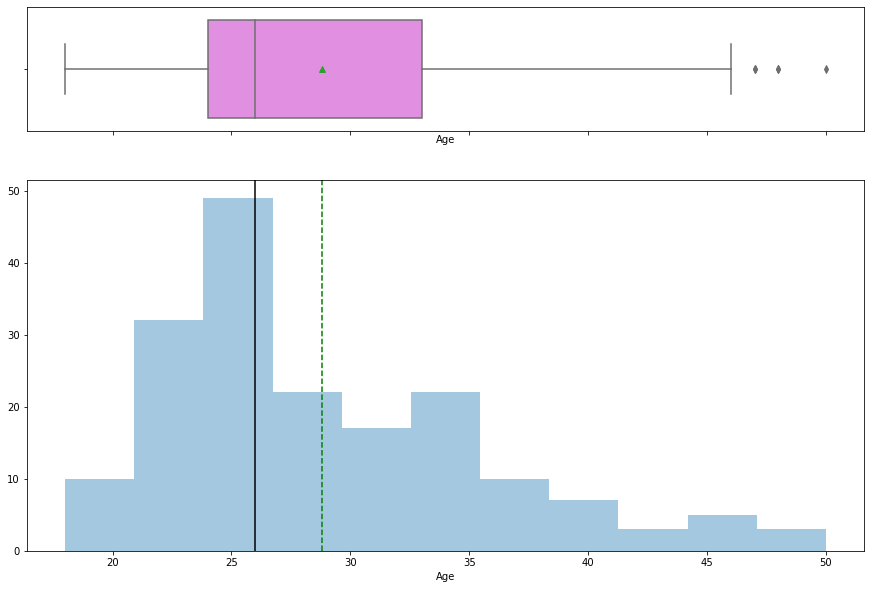

```python
histogram_boxplot(data["Age"])
```

Distribution is right skewed. Outliers present.

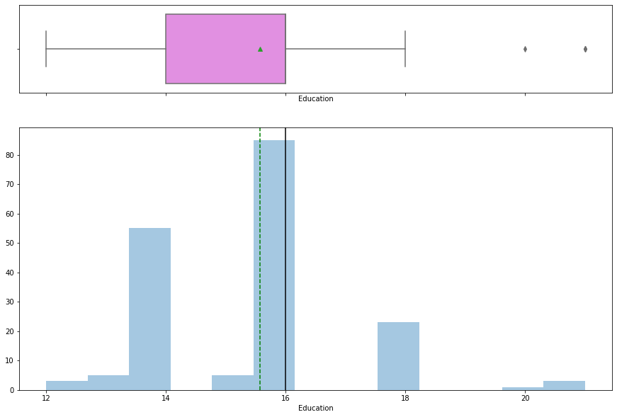

```python
histogram_boxplot(data["Education"])
```

Mean is 15.5 years Few ouliers.

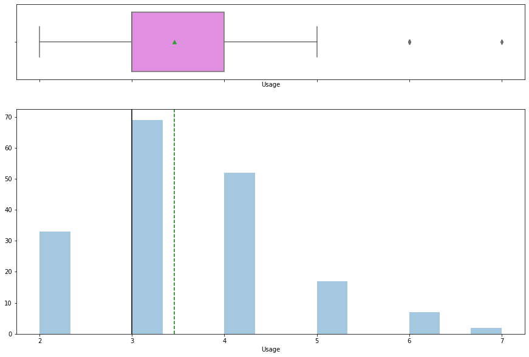

```python
histogram_boxplot(data["Usage"])
```

Customers use treadmills 3-4 times a week average. Few outliers.

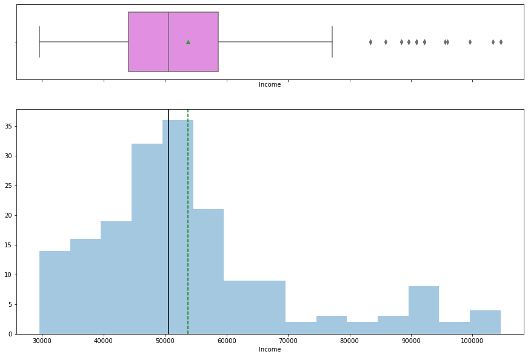

```python
histogram_boxplot(data["Income"])
```

Average income of customers who purchased product is around 55000. Right skewed distributions. Outliers present.

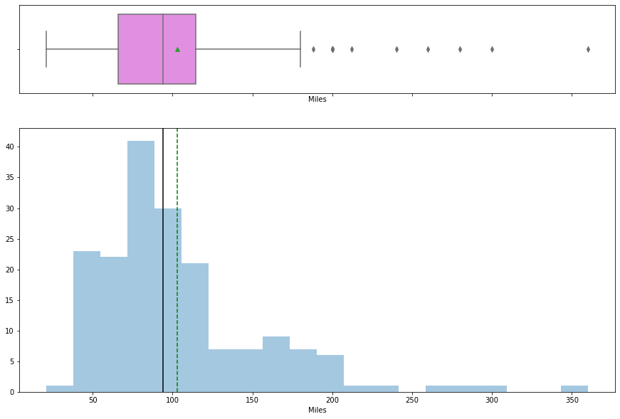

```python
histogram_boxplot(data["Miles"])
```

Most customers run 100 miles per week. Right skewed Outliers present.

```python
def perc_on_bar(plot, feature):
    '''
    plot
    feature: categorical feature
    the function won't work if a column is passed in hue parameter
    '''
    total = len(feature)
    for p in ax.patches:
        percentage = '{:.1f}%'.format(100 * p.get_height()/total)
        x = p.get_x() + p.get_width() / 2 - 0.05
        y = p.get_y() + p.get_height()
        ax.annotate(percentage, (x, y), size = 12)
    plt.show()
```

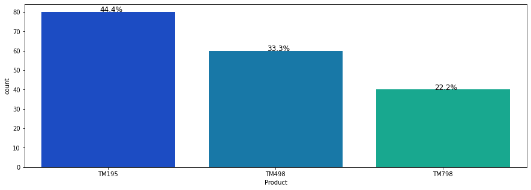

```python
plt.figure(figsize=(15,5))
ax = sns.countplot(data["Product"],palette='winter')
perc_on_bar(ax,data["Product"])
```

TM195 is top seller.

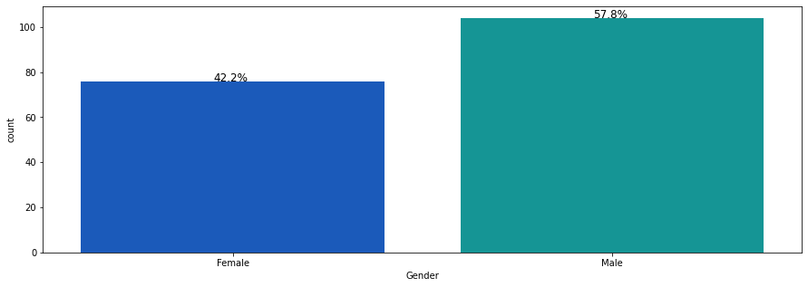

```python
plt.figure(figsize=(15,5))
ax = sns.countplot(data["Gender"],palette='winter')
perc_on_bar(ax,data["Gender"])
```

More male customers than female.

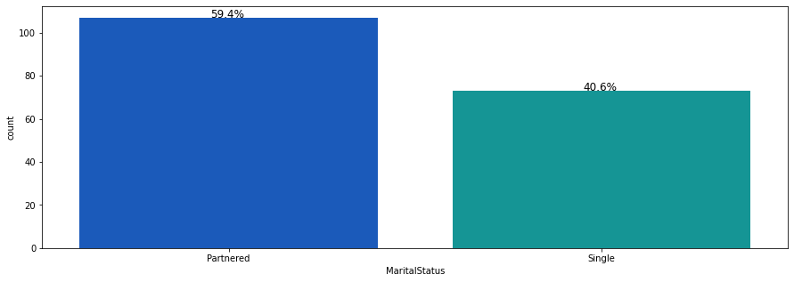

```python
plt.figure(figsize=(15,5))
ax = sns.countplot(data["MaritalStatus"],palette='winter')
perc_on_bar(ax,data["MaritalStatus"])
```

More partnered customers than single.

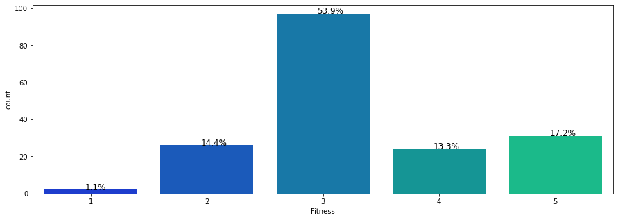

```python
plt.figure(figsize=(15,5))
ax = sns.countplot(data["Fitness"],palette='winter')
perc_on_bar(ax,data["Fitness"])
```

Most customers rate fitness at 3.

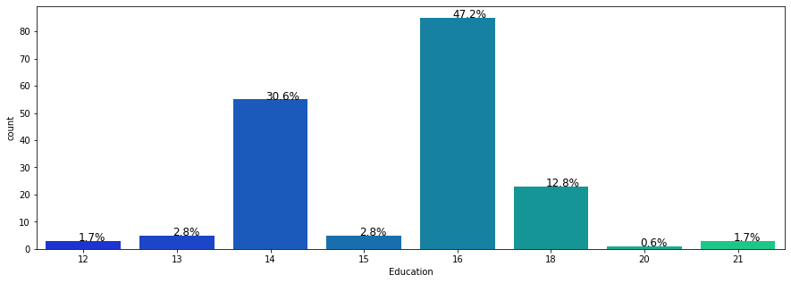

```python
plt.figure(figsize=(15,5))
ax = sns.countplot(data["Education"],palette='winter')
perc_on_bar(ax,data["Education"])
```

Most customers have 14, 16, 18 years of education.

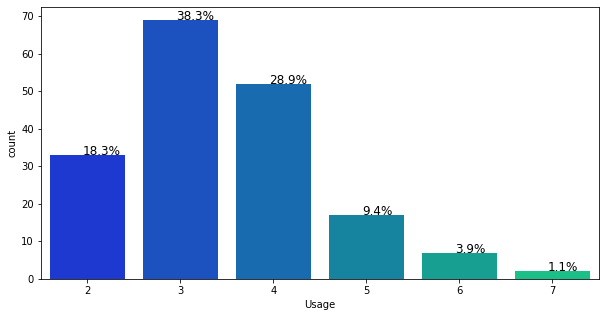

```python
plt.figure(figsize=(10,5))
ax = sns.countplot(data["Usage"],palette='winter')
perc_on_bar(ax,data["Usage"])
```

Most customers use products 3-4 times a week.

# Bivariate Analysis

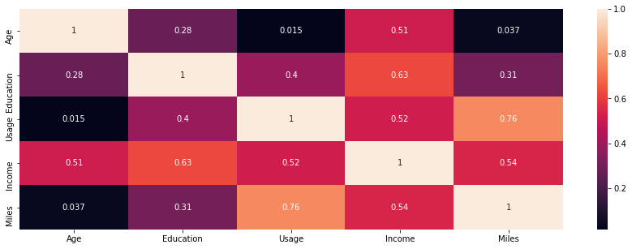

```python
plt.figure(figsize=(15,5))
sns.heatmap(data.corr(),annot=True)
plt.show()
```

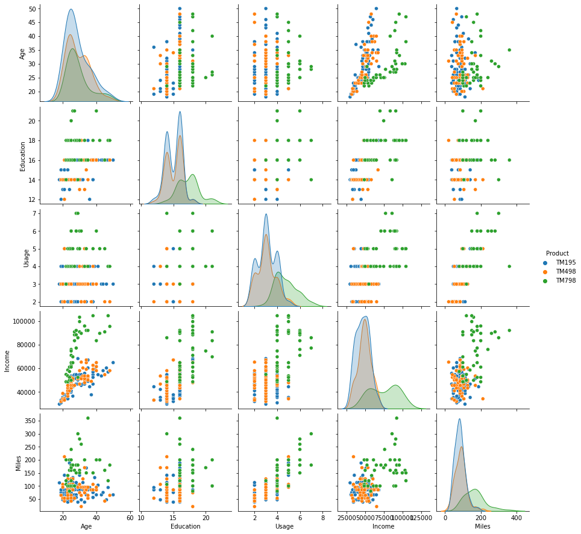

```python
sns.pairplot(data=data.drop(["Fitness"],axis=1),hue="Product")
plt.show()
```

All products show varying distributions.

Products/Age

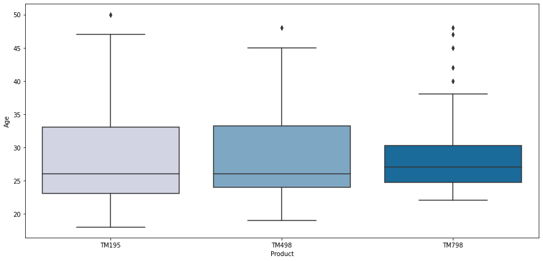

```python
plt.figure(figsize=(15,7))
sns.boxplot(data["Product"],data["Age"],palette="PuBu")
plt.show()
```

TM195 and TM498 show varing age groups. TM798 has age group between 22 and 38.

Product/Education

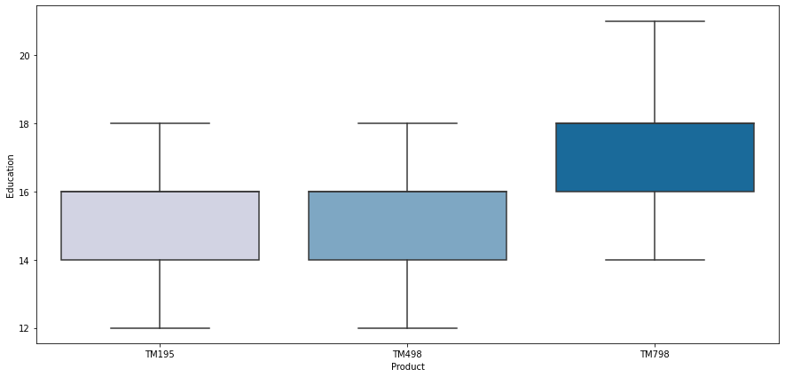

```python
plt.figure(figsize=(15,7))
sns.boxplot(data["Product"],data["Education"],palette="PuBu")
plt.show()
```

```python
TM798 shows higher educated customers.
```

Product/Usage

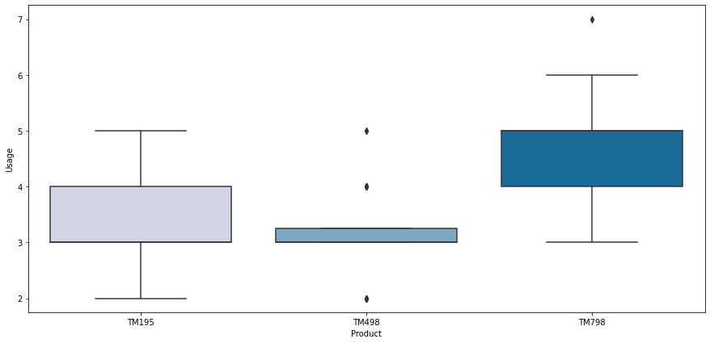

```python
plt.figure(figsize=(15,7))
sns.boxplot(data["Product"],data["Usage"],palette="PuBu")
plt.show()
```

Customers who have higher expected treadmill usage prefer the TM798 product. Customers with very light usage prefer TM498. Customers who have moderate usage prefer TM195.

Product/Income

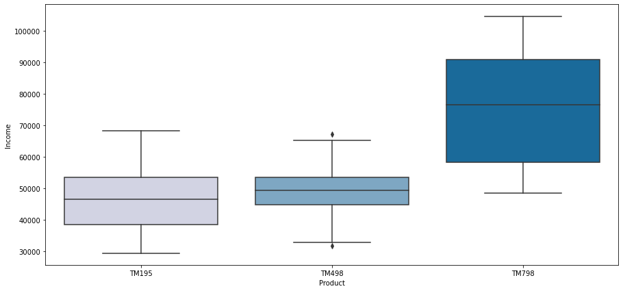

```python
plt.figure(figsize=(15,7))
sns.boxplot(data["Product"],data["Income"],palette="PuBu")
plt.show()
```

```python
Higher income customers prefer TM798.
```

Product/Miles

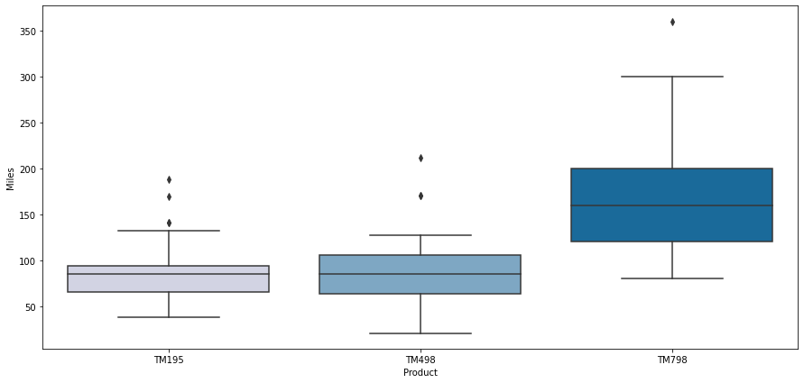

```python
plt.figure(figsize=(15,7))
sns.boxplot(data["Product"],data["Miles"],palette="PuBu")
plt.show()
```

```python
Higher mileage customers choose TM798
```

Product/Gender

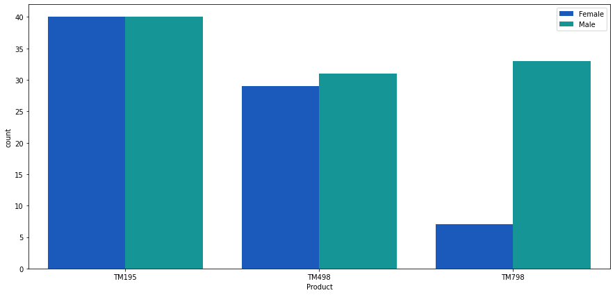

```python
plt.figure(figsize=(15,7))
sns.countplot(data["Product"],hue=data["Gender"],palette='winter')
plt.legend(bbox_to_anchor=(1.00, 1))
plt.show()
```

TM195 and TM498 are purchased equally between males and females. TM798 is purchased more by males.

Product/Marital Status

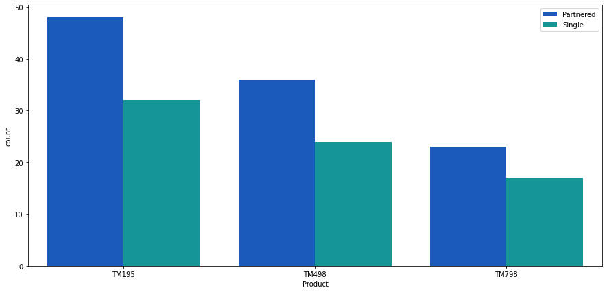

```python
plt.figure(figsize=(15,7))
sns.countplot(data["Product"],hue=data["MaritalStatus"],palette='winter')
plt.legend(bbox_to_anchor=(1.00, 1))
plt.show()
```

```python
Partnered customers more likely to purchase products.
```

Product/Fitness

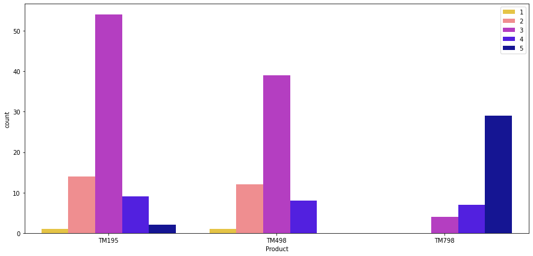

```python
plt.figure(figsize=(15,7))
sns.countplot(data["Product"],hue=data["Fitness"],palette="gnuplot2_r")
plt.legend(bbox_to_anchor=(1.00, 1))
plt.show()
```

Customers who purchased TM195 and TM498 gave themselves a rating of 3. TM798 most of customers gave themselves higher in fitness rating of 5.

# Grouping data to products for customer profiles

TM195

```python
data[data["Product"]=="TM195"].describe(include="all")
```

|  | Product | Age | Gender | Education | MaritalStatus | Usage | Fitness | Income | Miles |
| --- | --- | --- | --- | --- | --- | --- | --- | --- | --- |
| count | 80 | 80.000000 | 80 | 80.000000 | 80 | 80.000000 | 80.0 | 80.00000 | 80.000000 |
| unique | 1 | NaN | 2 | NaN | 2 | NaN | 5.0 | NaN | NaN |
| top | TM195 | NaN | Male | NaN | Partnered | NaN | 3.0 | NaN | NaN |
| freq | 80 | NaN | 40 | NaN | 48 | NaN | 54.0 | NaN | NaN |
| mean | NaN | 28.550000 | NaN | 15.037500 | NaN | 3.087500 | NaN | 46418.02500 | 82.787500 |
| std | NaN | 7.221452 | NaN | 1.216383 | NaN | 0.782624 | NaN | 9075.78319 | 28.874102 |
| min | NaN | 18.000000 | NaN | 12.000000 | NaN | 2.000000 | NaN | 29562.00000 | 38.000000 |
| 25% | NaN | 23.000000 | NaN | 14.000000 | NaN | 3.000000 | NaN | 38658.00000 | 66.000000 |
| 50% | NaN | 26.000000 | NaN | 16.000000 | NaN | 3.000000 | NaN | 46617.00000 | 85.000000 |
| 75% | NaN | 33.000000 | NaN | 16.000000 | NaN | 4.000000 | NaN | 53439.00000 | 94.000000 |
| max | NaN | 50.000000 | NaN | 18.000000 | NaN | 5.000000 | NaN | 68220.00000 | 188.000000 |

The TM195 customer is our regular customer (since this product is sold more than others). Early 20’s to early 30’s. 12-18 years of educataion. Income between 40K and 50K. Plans to use treadmill three to four times per week. Has an average fitness level of 3.

```python
data[data["Product"]=="TM498"].describe(include="all")
```

|  | Product | Age | Gender | Education | MaritalStatus | Usage | Fitness | Income | Miles |
| --- | --- | --- | --- | --- | --- | --- | --- | --- | --- |
| count | 60 | 60.000000 | 60 | 60.000000 | 60 | 60.000000 | 60.0 | 60.000000 | 60.000000 |
| unique | 1 | NaN | 2 | NaN | 2 | NaN | 4.0 | NaN | NaN |
| top | TM498 | NaN | Male | NaN | Partnered | NaN | 3.0 | NaN | NaN |
| freq | 60 | NaN | 31 | NaN | 36 | NaN | 39.0 | NaN | NaN |
| mean | NaN | 28.900000 | NaN | 15.116667 | NaN | 3.066667 | NaN | 48973.650000 | 87.933333 |
| std | NaN | 6.645248 | NaN | 1.222552 | NaN | 0.799717 | NaN | 8653.989388 | 33.263135 |
| min | NaN | 19.000000 | NaN | 12.000000 | NaN | 2.000000 | NaN | 31836.000000 | 21.000000 |
| 25% | NaN | 24.000000 | NaN | 14.000000 | NaN | 3.000000 | NaN | 44911.500000 | 64.000000 |
| 50% | NaN | 26.000000 | NaN | 16.000000 | NaN | 3.000000 | NaN | 49459.500000 | 85.000000 |
| 75% | NaN | 33.250000 | NaN | 16.000000 | NaN | 3.250000 | NaN | 53439.000000 | 106.000000 |
| max | NaN | 48.000000 | NaN | 18.000000 | NaN | 5.000000 | NaN | 67083.000000 | 212.000000 |

The TM498 customers is similar to the TM195 customer. The differences are that these customers have higher annual income, dless usage, and more miles to run each week. TM498 customer is a working adult with a busy schedule lower usage.

Adult in their mid 20’s to early 30’s 12-18 years of educatation. Income around 50K. Plans to use treadmill three days a week. Average fitness level.

```python
data[data["Product"]=="TM798"].describe(include="all")
```

|  | Product | Age | Gender | Education | MaritalStatus | Usage | Fitness | Income | Miles |
| --- | --- | --- | --- | --- | --- | --- | --- | --- | --- |
| count | 40 | 40.000000 | 40 | 40.000000 | 40 | 40.000000 | 40.0 | 40.00000 | 40.000000 |
| unique | 1 | NaN | 2 | NaN | 2 | NaN | 3.0 | NaN | NaN |
| top | TM798 | NaN | Male | NaN | Partnered | NaN | 5.0 | NaN | NaN |
| freq | 40 | NaN | 33 | NaN | 23 | NaN | 29.0 | NaN | NaN |
| mean | NaN | 29.100000 | NaN | 17.325000 | NaN | 4.775000 | NaN | 75441.57500 | 166.900000 |
| std | NaN | 6.971738 | NaN | 1.639066 | NaN | 0.946993 | NaN | 18505.83672 | 60.066544 |
| min | NaN | 22.000000 | NaN | 14.000000 | NaN | 3.000000 | NaN | 48556.00000 | 80.000000 |
| 25% | NaN | 24.750000 | NaN | 16.000000 | NaN | 4.000000 | NaN | 58204.75000 | 120.000000 |
| 50% | NaN | 27.000000 | NaN | 18.000000 | NaN | 5.000000 | NaN | 76568.50000 | 160.000000 |
| 75% | NaN | 30.250000 | NaN | 18.000000 | NaN | 5.000000 | NaN | 90886.00000 | 200.000000 |
| max | NaN | 48.000000 | NaN | 21.000000 | NaN | 7.000000 | NaN | 104581.00000 | 360.000000 |

T798 customer is mostly male. Highly educated. Higher income. Plans to use treadmill 4-5 days a week, running 167 miles on an average. Considers themselves very fit.

Gender/Usage/Marital Status

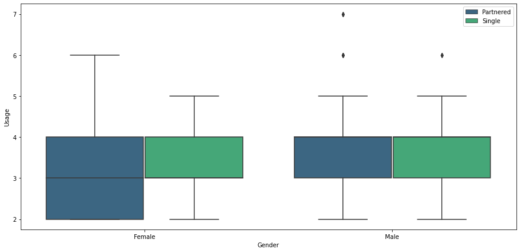

```python
plt.figure(figsize=(15,7))
sns.boxplot(data["Gender"],data["Usage"],hue=data["MaritalStatus"],palette="viridis")
plt.legend(bbox_to_anchor=(1.00, 1))
plt.show()
```

Single females, married and unmarried males have similar usage.

Gender/Income

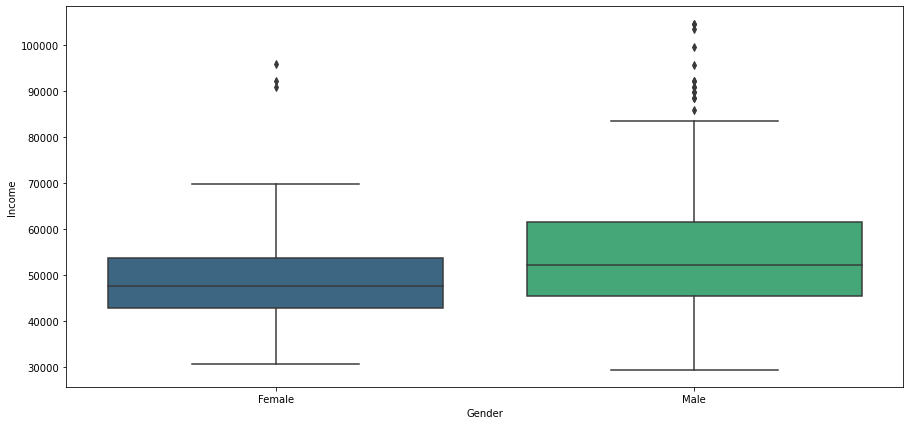

```python
plt.figure(figsize=(15,7))
sns.boxplot(data["Gender"],data["Income"],palette="viridis")
plt.show()
```

More males with higher income than females.

Gender/Income/Marital Status

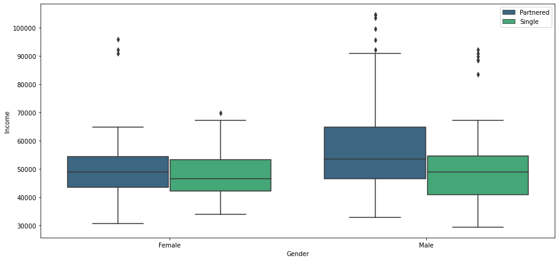

```python
plt.figure(figsize=(15,7))
sns.boxplot(data["Gender"],data["Income"],hue=data["MaritalStatus"],palette="viridis")
plt.legend(bbox_to_anchor=(1.00, 1))
plt.show()
```

Males with parnter have higher income. All others very similar.

Gender/Miles

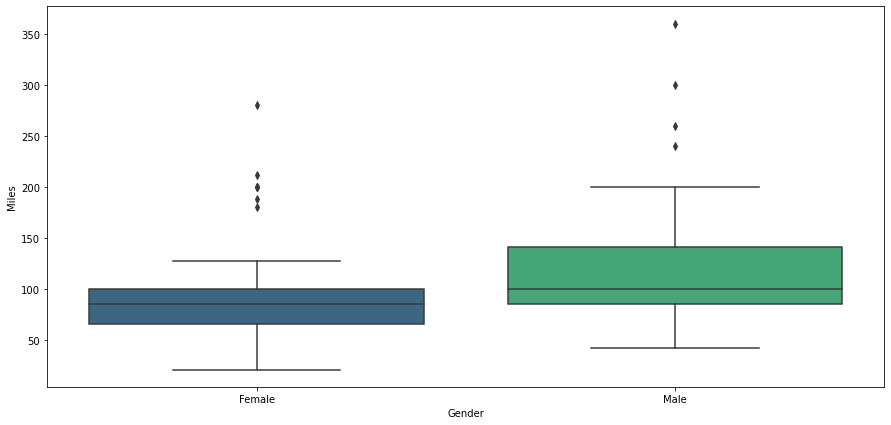

```python
plt.figure(figsize=(15,7))
sns.boxplot(data["Gender"],data["Miles"],palette="viridis")
plt.show()
```

```python
Males run more miles.
```

Gender/Miles/Marital Status

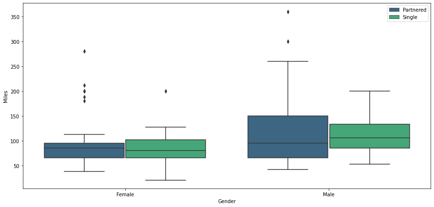

```python
plt.figure(figsize=(15,7))
sns.boxplot(data["Gender"],data["Miles"],hue=data["MaritalStatus"],palette="viridis")
plt.legend(bbox_to_anchor=(1.00, 1))
plt.show()
```

Single and partnered males run more miles.

Gender/Miles/Education

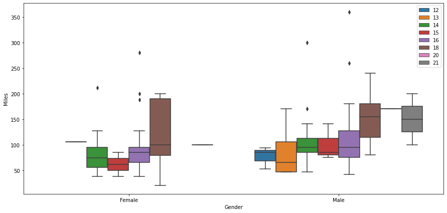

```python
plt.figure(figsize=(15,7))
sns.boxplot(data["Gender"],data["Miles"],hue=data["Education"])
plt.legend(bbox_to_anchor=(1.00, 1))
plt.show()
```

```python
Higher educated customers run more.
```

Age/Miles/Gender

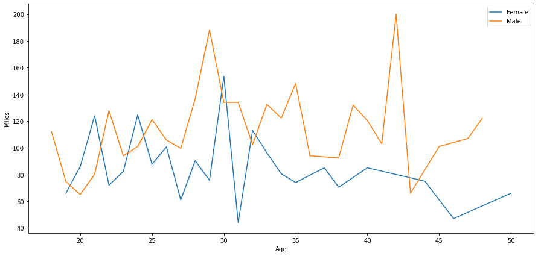

```python
plt.figure(figsize=(15,7))
sns.lineplot(data["Age"],data["Miles"],hue=data["Gender"],ci=0)
plt.legend(bbox_to_anchor=(1.00, 1))
plt.show()
```

Age/Miles/Marital Status

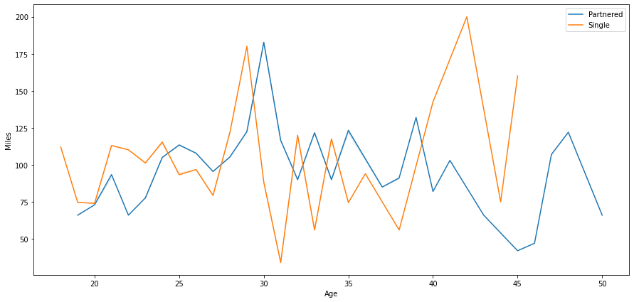

```python
plt.figure(figsize=(15,7))
sns.lineplot(data["Age"],data["Miles"],hue=data["MaritalStatus"],ci=0)
plt.legend(bbox_to_anchor=(1.00, 1))
plt.show()
```

Age/Income/Product

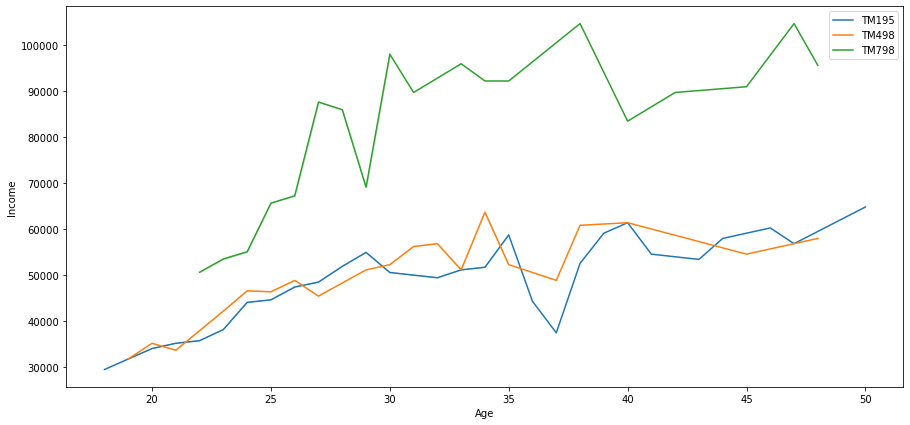

```python
plt.figure(figsize=(15,7))
sns.lineplot(data["Age"],data["Income"],hue=data["Product"],ci=0)
plt.legend(bbox_to_anchor=(1.00, 1))
plt.show()
```

TM195 and TM498 indicate customers income level 30K-60K all age groups. TM798 is purchased by higher income customers only for all age groups.

Income/Miles/Education

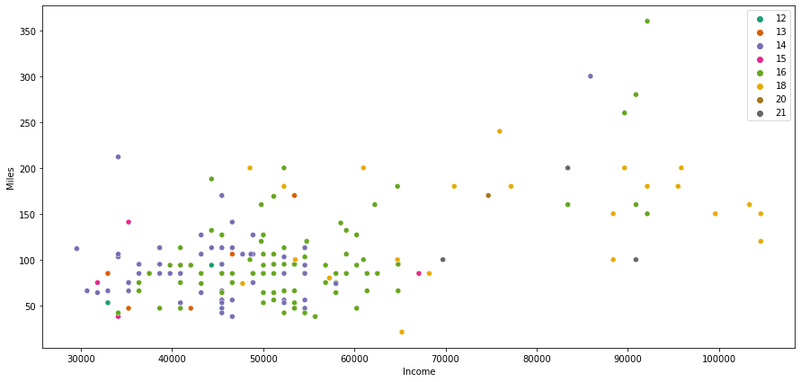

```python
plt.figure(figsize=(15,7))
sns.scatterplot(data["Income"],data["Miles"],hue=data["Education"],ci=0.,palette="Dark2")
plt.legend(bbox_to_anchor=(1.00, 1))
plt.show()
```

Income/Miles/Product

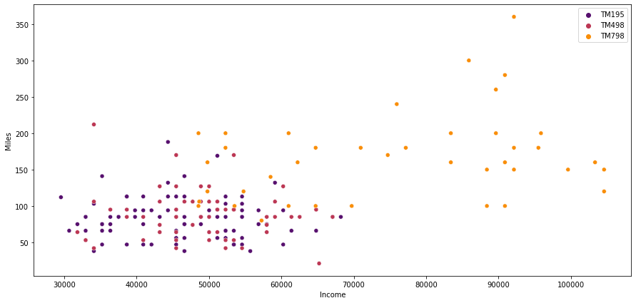

```python
plt.figure(figsize=(15,7))
sns.scatterplot(data["Income"],data["Miles"],hue=data["Product"],ci=0,palette="inferno")
plt.legend(bbox_to_anchor=(1.00, 1))
plt.show()
```

Customers having an income of more than 70k tend to buy TM798 and run more miles.

# Conclusion

TM195:

- Least expensive entry-level treadmill that can be used by a wide range of users.
- Customers with light to moderate usage 3 to 4 times a week go for this product.

- Still affordable, but a higher price than TM195. Comes with more features.
- The product also generally targets the same age group as the TM195 but with a higher income level.
- The product is used 3 times per week.

TM798:

- High-end treadmill.
- It has a higher price point and probably the flagship product of the company.
- Highest fitness levels and most miles and usage.
- Highest education levels and income.
- Male customers prefer this product more than females.

Business Insights:

- The company needs to engage in more marketing for product TM798 to both the genders and to younger age groups. Currently it seems TM798 is marketed as an exclusive product for the males making more money.
- Years of education are proportionate to income so customers with higher education should be recommended TM798.
- Females above 30 years should be recommended the lower end products since they run fewer miles.
- Partnered Females can be recommended all types of products since their usage varies greatly.
- Singles above 40 years can be recommended TM798 since they wish to run more miles.
- Partnered males have a higher income and also run more miles so TM798 should be recommended.